# Clustering with Prostate Cancer

## Final for Unsupervised Learning

#### 2021.03.24

# I. Introduction

Prostate health is a [serious and widespread concern](https://www.cancer.org/cancer/prostate-cancer/about/key-statistics.html) for men in the US. This data set explores some response variables from a sample [dataset](https://web.stanford.edu/~hastie/ElemStatLearn/data.html).

# II. Data

For my final project, I chose the prostate cancer data from [Datasets for "The Elements of Statistical Learning](https://web.stanford.edu/~hastie/ElemStatLearn/data.html).

## 1. Packages

```python
import math
import matplotlib.pyplot as plt
from matplotlib.ticker import StrMethodFormatter as SMF
import numpy as np
import pandas as pd
from scipy.spatial.distance import cdist
import seaborn as sns
from warnings import filterwarnings as fw
fw("ignore")
```

## 2. Read Data

Details can be found [here](http://search.r-project.org/library/ElemStatLearn/html/prostate.html).

```python
prostate = pd.read_table("https://web.stanford.edu/~hastie/ElemStatLearn/datasets/prostate.data", sep = "\t", index_col = 0)
prostate = prostate[['age', 'lbph', 'lcp',
                     'lcavol', 'lweight', 'pgg45',
                     'gleason', 'lpsa', 'svi']].rename(columns = {"age": "Age",
                                                                  "lbph": "logBPH",
                                                                  "lcp": "logCP",
                                                                  "lcavol": "logCV",
                                                                  "lweight": "logPW",
                                                                  "pgg45": "Gleason2",
                                                                  "gleason": "Gleason1",
                                                                  "lpsa": "logPSA",
                                                                  "svi": "SVI"})
prostate
```

|  | Age | logBPH | logCP | logCV | logPW | Gleason2 | Gleason1 | logPSA | SVI |
| --- | --- | --- | --- | --- | --- | --- | --- | --- | --- |
| 1 | 50 | -1.386294 | -1.386294 | -0.579818 | 2.769459 | 0 | 6 | -0.430783 | 0 |
| 2 | 58 | -1.386294 | -1.386294 | -0.994252 | 3.319626 | 0 | 6 | -0.162519 | 0 |
| 3 | 74 | -1.386294 | -1.386294 | -0.510826 | 2.691243 | 20 | 7 | -0.162519 | 0 |
| 4 | 58 | -1.386294 | -1.386294 | -1.203973 | 3.282789 | 0 | 6 | -0.162519 | 0 |
| 5 | 62 | -1.386294 | -1.386294 | 0.751416 | 3.432373 | 0 | 6 | 0.371564 | 0 |
| ... | ... | ... | ... | ... | ... | ... | ... | ... | ... |
| 93 | 68 | -1.386294 | 1.321756 | 2.830268 | 3.876396 | 60 | 7 | 4.385147 | 1 |
| 94 | 44 | -1.386294 | 2.169054 | 3.821004 | 3.896909 | 40 | 7 | 4.684443 | 1 |
| 95 | 52 | -1.386294 | 2.463853 | 2.907447 | 3.396185 | 10 | 7 | 5.143124 | 1 |
| 96 | 68 | 1.558145 | 1.558145 | 2.882564 | 3.773910 | 80 | 7 | 5.477509 | 1 |
| 97 | 68 | 0.438255 | 2.904165 | 3.471966 | 3.974998 | 20 | 7 | 5.582932 | 1 |

97 rows × 9 columns

## 3. Objective

The objective of this study is cluster groups of men based off metrics related to prostate and reproductive health.

# III. Exploratory Data Analysis

There are no missing values and several variables have already been log transformed.

## 1. Distributions and Histograms

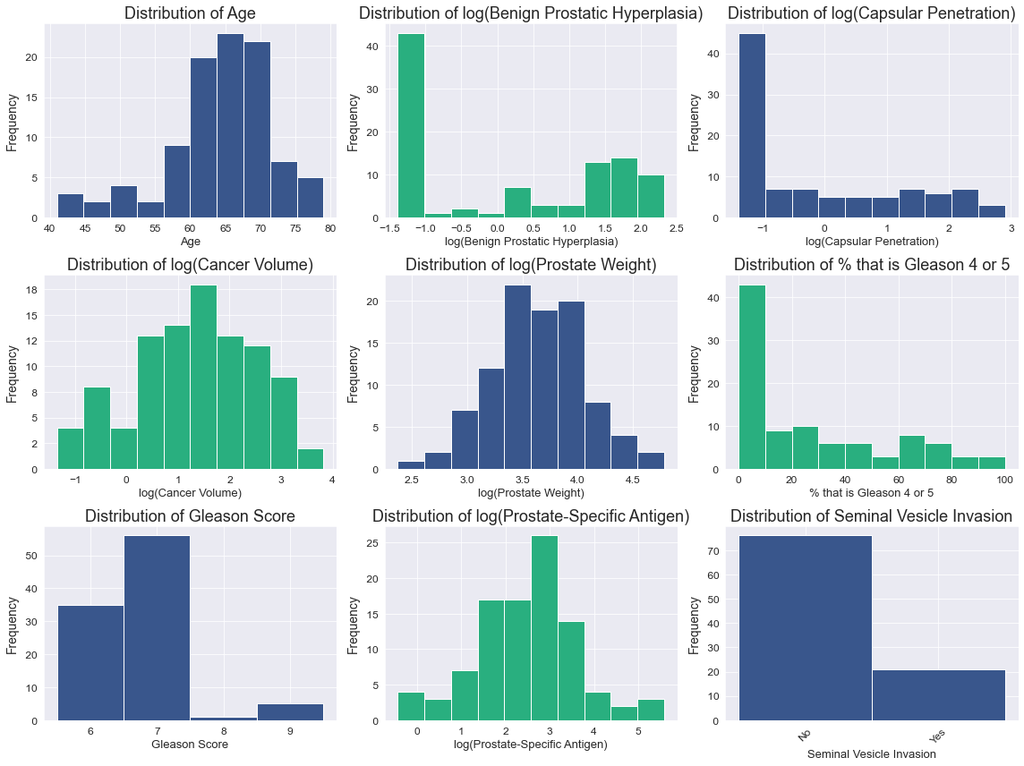

```python
sns.set_style('darkgrid')

def hist_helper(df, ax, var, name, b, c):
    ax.hist(df[var],
            bins = b,
            color = [c],
            stacked = True)
    ax.set_title("Distribution of " + name, fontsize = 18)
    ax.set_xlabel(xlabel = name, fontsize = 13)
    if (var == 'SVI'):
        plt.sca(ax)
        plt.xticks(ticks = [0.25, 0.75], labels = ['No', 'Yes'], ha = 'center', rotation = 45)
    elif (var == 'Gleason1'):
        plt.sca(ax)
        plt.xticks(ticks = [6.375, 7.125, 7.875, 8.625], labels = [6, 7, 8, 9])
    ax.set_ylabel(ylabel = "Frequency", fontsize = 14)
    ax.yaxis.set_major_formatter(SMF('{x: ,.0f}'))
    ax.tick_params(axis = 'both', labelsize = 12)

fig, ax = plt.subplots(3, 3, figsize = (16, 12))

c1 = '#39568CFF'
c2 = '#29AF7FFF'

hist_helper(prostate, ax[0][0], 'Age', 'Age', 10, c1)
hist_helper(prostate, ax[0][1], 'logBPH', 'log(Benign Prostatic Hyperplasia)', 10, c2)
hist_helper(prostate, ax[0][2], 'logCP', 'log(Capsular Penetration)', 10, c1)

hist_helper(prostate, ax[1][0], 'logCV', 'log(Cancer Volume)', 10, c2)
hist_helper(prostate, ax[1][1], 'logPW', 'log(Prostate Weight)', 10, c1)
hist_helper(prostate, ax[1][2], 'Gleason2', '% that is Gleason 4 or 5', 10, c2)


hist_helper(prostate, ax[2][0], 'Gleason1', 'Gleason Score', 4, c1)
hist_helper(prostate, ax[2][1], 'logPSA', 'log(Prostate-Specific Antigen)', 10, c2)
hist_helper(prostate, ax[2][2], 'SVI', 'Seminal Vesicle Invasion', 2, c1)

fig.tight_layout()
fig.savefig('Unsupervised1 - Histograms.png');
```

## 2. Skew

```python
float_columns = [x for x in prostate.columns if x not in ['Gleason1', 'SVI']]

prostate[float_columns].skew().sort_values()
```

```
Age        -0.828476
logCV      -0.250304
logPSA     -0.000434
logPW       0.063541
logBPH      0.133813
logCP       0.728634
Gleason2    0.968105
dtype: float64
```

`Age` is left skewed.

`logCV`, `logPSA`, and `logPW` have been appropriately log transformed and are close to normal distribution.

`logBPH`, `logCP`, and `Gleason2` all have over 40% of their observations in the least value bin.

`Gleason1` and `SVI` are both categorical and are unbalanced.

## 3. Correlation

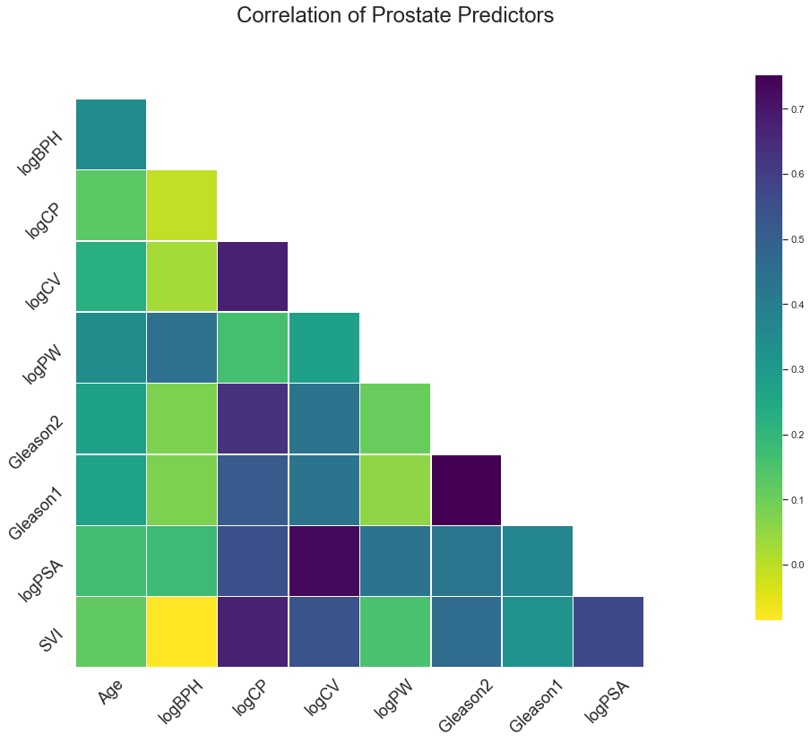

```python
#https://seaborn.pydata.org/examples/many_pairwise_correlations.html
sns.set_theme(style = "white")

# Compute the correlation matrix.
corr = prostate.corr()

#Maximum and minimum.
vmax = corr[corr < 1].max().max()
vmin = corr.min().min()

# Generate a mask for the upper triangle.
mask = np.triu(np.ones_like(corr, dtype = bool))

# Set up the matplotlib figure.
fig, ax = plt.subplots(figsize = (16, 16))

# Draw the heatmap with the mask and correct aspect ratio.
sns.heatmap(corr,
            mask = mask,
            cmap = 'viridis_r',
            vmax = vmax,
            vmin = vmin,
            square = True,
            linewidths = .5,
            cbar_kws = {"shrink": .7})

plt.title("Correlation of Prostate Predictors", fontsize = 24)
xl, xt = plt.xticks()
plt.xticks(ticks = xl[0:-1],
           labels = xt[0:-1],
           fontsize = 18,
           ha = 'center',
           rotation = 45);

yl, yt = plt.yticks()
plt.yticks(ticks = yl[1:],
           labels = yt[1:],
           fontsize = 18,
           rotation = 45)

fig.savefig('Unsupervised2 - Correlations.png');
```

`Gleason1` and `Gleason2` have the highest correlation at around 0.75.

`logCV` and `logPSA`, `logCP` and `logCV`, and `logCP` and `SVI` also have high correlations.

No variables will be removed, as multicollinearity is not an issue.

# IV. Clustering Models

The data will be split into training (70%) and validation (30%) sets.

I am using three usupervised learning algorithms:

- K-Means Clustering - comparing 1 to 10 clusters. An elbow plot will be used to determine the optimal cluster size.
- Hierarchical Agglomerative Clustering - using the *euclidean* for affinity and *ward* for linkage. The result is expressed as a dendrogram.
- MeanShift Clustering

For each of the three models, the cluster results of the train set will be represented as the color in a grid of pair-plots for all nine variables.

```python
from sklearn.model_selection import train_test_split as TTS
train, validation = TTS(prostate, test_size = 0.3, random_state = 31313)



#Create grid of pairplots, colored by cluster labels.
def pair_plot(df, model, name, palette, f):

    #Append cluster labels to train data.
    temp = pd.DataFrame.copy(df)
    temp[name] = model.labels_

    #Setup.
    sns.set_style('darkgrid')
    sns.set(font_scale = 1.75)

    #Pairplot setup.
    g = sns.pairplot(temp,
                 hue = name,
                 palette = palette,
                 markers = 'd',
                 corner = True,
                 height = 2,
                 plot_kws = {'s': 40,
                             'alpha': 0.8,
                             'lw': 0.5,
                             'edgecolor': 'k'})

    #Set main title.
    g.fig.suptitle("Pairwise Scatter Plots by Cluster (" + name + ")",
                   y = .98,
                   size = 32)

    #Remove legend.
    g._legend.remove()

    #Create new legend
    l = g.fig.legend(title = 'Cluster',
                     handles = g._legend_data.values(),
                     labels = g._legend_data.keys(),
                     fontsize = '24',
                     title_fontsize = '28',
                     ncol = 1,
                     frameon = False)

    #Legend location and background.
    l.set_bbox_to_anchor((0.88, 0.65))
    l.get_frame().set_facecolor('white')

    g.savefig("Unsupervised" + f + ' - ' + name + '.png');
```

## 1. KMeans Clustering

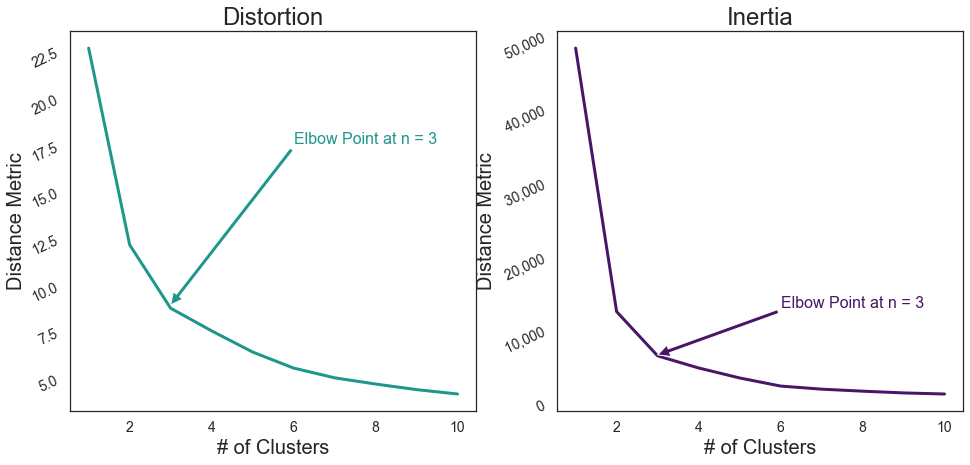

```python
from sklearn.cluster import KMeans as KM

distortions = []
inertias = []
centers = []
K = range(1, 11)

for k in K:

    # Building and fitting the model
    model_km = KM(n_clusters = k, init = 'k-means++').fit(train)

    distortions.append(sum(np.min(cdist(train, model_km.cluster_centers_, 'euclidean'), axis=1)) / train.shape[0])
    inertias.append(model_km.inertia_)
    centers.append(model_km.cluster_centers_)

#Graph helper
def elbow_graph(axis, title, y, c) :

    sns.set_theme(style = "darkgrid")

    #Lines.
    axis.plot(K, y, lw = 3, color = c)

    #Subtitle.
    axis.set_title(title, fontsize = 24)

    #Axes.
    axis.set_xlabel("# of Clusters", fontsize = 20)
    axis.set_ylabel("Distance Metric", fontsize = 20)
    for tick in axis.get_yticklabels():
        tick.set_rotation(25)
    if (title == "Inertia"):
        axis.yaxis.set_major_formatter(SMF('{x: ,.0f}'))
    axis.tick_params(axis = 'both', labelsize = 14)

    axis.annotate('Elbow Point at n = 3',
            xy = (3, 1.02 * y[2]),
            xytext = (6, 2 * y[2]),
            fontsize = 16,
            color = c,
            arrowprops = dict(facecolor = c,
                              connectionstyle = "arc3, rad = 0"))


#Full graph.
fig, (ax1, ax2) = plt.subplots(1, 2, figsize = (16, 7))

elbow_graph(ax1, "Distortion", distortions, '#1F968B')

elbow_graph(ax2, "Inertia", inertias, '#481567')

fig.savefig('Unsupervised3 - Elbow.png');
```

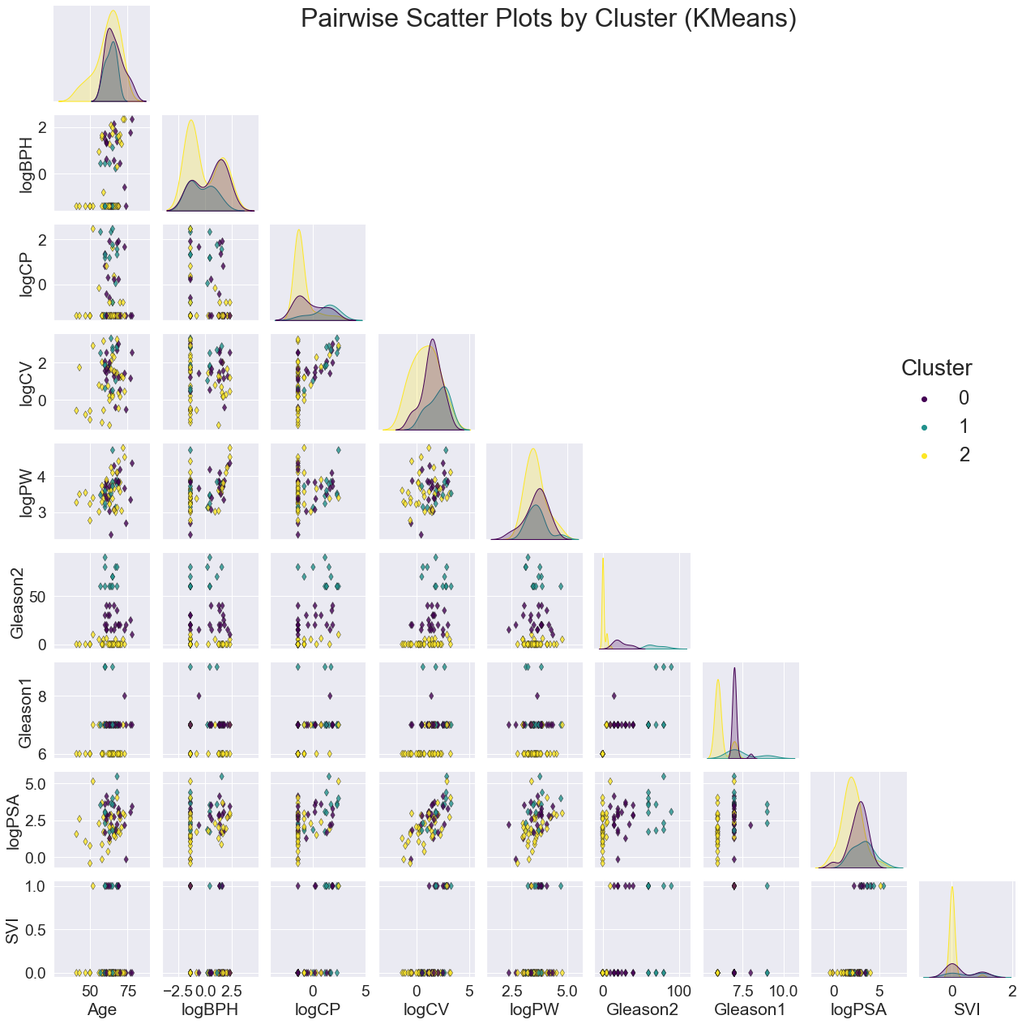

```python
model_k = KM(n_clusters = 3, init = 'k-means++').fit(train)

pair_plot(train, model_k, 'KMeans', 'viridis', '4')
```

## 2. Hierarchical Agglomerative Clustering

```python
from scipy.cluster.hierarchy import dendrogram as D
from scipy.cluster.hierarchy import set_link_color_palette as SLCP
from sklearn.cluster import AgglomerativeClustering as AC

#https://scikit-learn.org/stable/auto_examples/cluster/plot_agglomerative_dendrogram.html
def plot_dendrogram(model, **kwargs):
    # Create linkage matrix and then plot the dendrogram

    # create the counts of samples under each node
    counts = np.zeros(model.children_.shape[0])
    n_samples = len(model.labels_)
    for i, merge in enumerate(model.children_):
        current_count = 0
        for child_idx in merge:
            if child_idx < n_samples:
                current_count += 1  # leaf node
            else:
                current_count += counts[child_idx - n_samples]
        counts[i] = current_count

    linkage_matrix = np.column_stack([model.children_, model.distances_,
                                      counts]).astype(float)

    # Plot the corresponding dendrogram
    SLCP(("#FDE725",
          "#2D708E",
          "#73D055",
          "#453781",
          "#20A387",
          "#440154"))

    D(linkage_matrix, color_threshold = 45, above_threshold_color = 'grey', **kwargs)
```

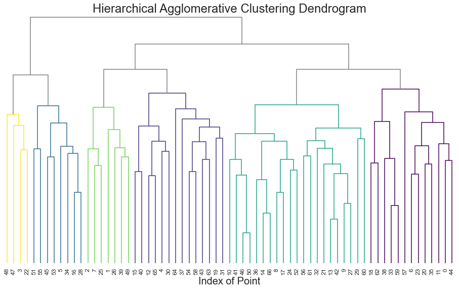

```python
model_a = AC(distance_threshold = 0, n_clusters = None, linkage = 'ward').fit(train)
sns.set_style('white')

fig = plt.figure(figsize = (16, 9))
#https://scikit-learn.org/stable/auto_examples/cluster/plot_agglomerative_dendrogram.html
plt.title('Hierarchical Agglomerative Clustering Dendrogram', fontsize = 24)
plot_dendrogram(model_a, truncate_mode = 'level', p = 9)
plt.xlabel("Index of Point", fontsize = 20)

#Remove axes and ticks.
ax = plt.gca()
for side in ["top", "right", "bottom", "left"]:
    ax.spines[side].set_visible(False)

plt.yscale("symlog")
ax.set_yticks([])
ax.tick_params(axis = 'both', labelsize = 12)


fig.savefig('Unsupervised5 - Dendrogram.png');
```

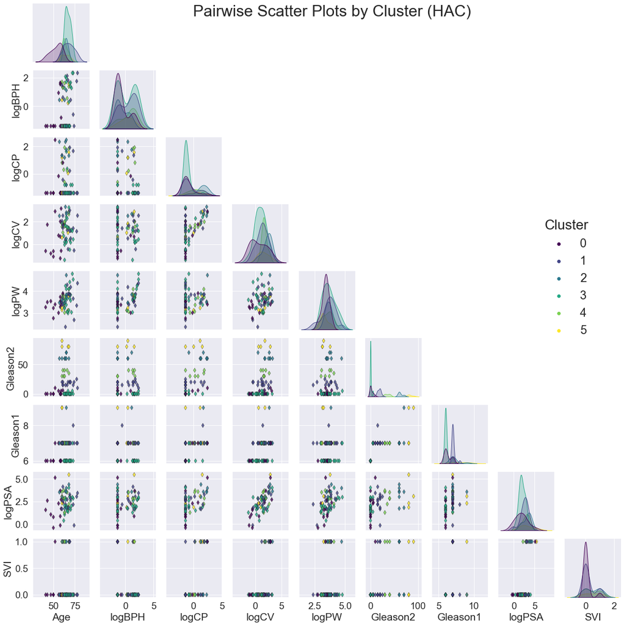

```python
model_h = AC(n_clusters = 6, linkage = 'ward').fit(train)

pair_plot(train, model_h, 'HAC', 'viridis', '6')
```

## 3. MeanShift Clustering

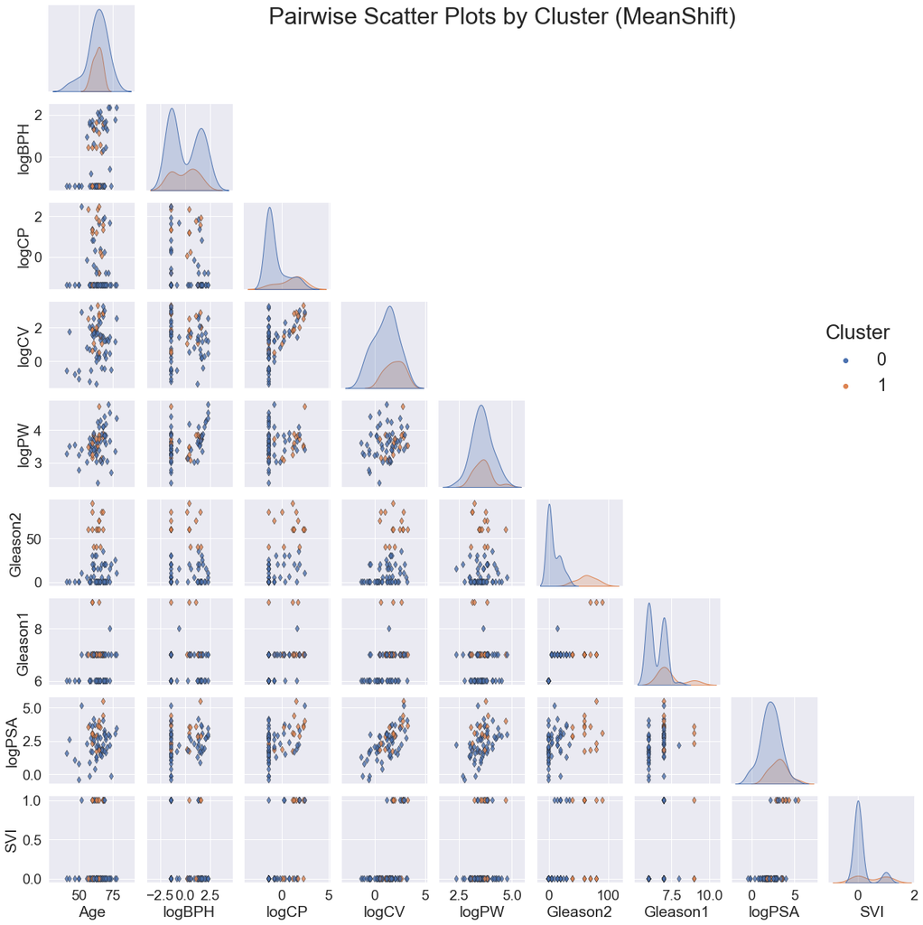

```python
from sklearn.cluster import MeanShift as MS

model_m = MS().fit(train)

palette = sns.set_palette(sns.color_palette(['#1F968B', '#481567']))

pair_plot(train, model_m, 'MeanShift', palette, '7')
```

# V. Final Model Selection

Hierarchical Agglomerative Clustering was chosen as the final model.

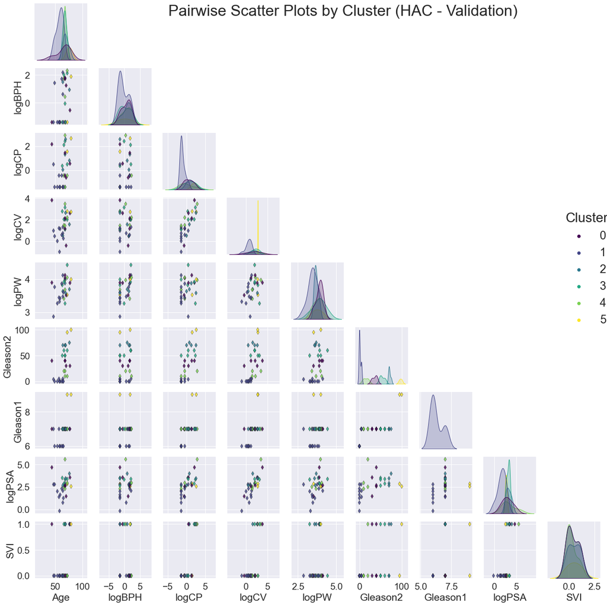

```python
model_h_final = model_h.fit(validation)

pair_plot(validation, model_h_final, 'HAC - Validation', 'viridis', '8')
```